# STAT 415 Lab 2

Solutions

# 1 Introduction

In the handouts we have focused on inference for a population proportion. This lab will introduce you to another of the most common problems in statistics: inference for a population mean of a numerical variable. You will apply a process similar to what we covered in handouts to perform Bayesian inference for a population mean. This lab will make some simplifying assumptions to illustrate the basic process and ideas. We’ll consider more realistic scenarios later.

**Important note regarding code:** We will cover code for performing and summarizing Bayesian analyses in much more detail throughout the course. Early in the course I have tried to keep the code as simple and bare bones as possible, especially with respect to plotting. There are certainly better ways to code, especially better plots that could be made. You are welcome to jazz it up (or tidyverse it up) if you want, but it’s certainly not required. The main goal for this lab is to understand the basic process.

# 2 Instructions

This RMarkdown file provides a template for you to fill in. **Read the file from start to finish, completing the parts as indicated.** **Some code is provided for you. Be sure to run this code, and make sure you understand what it’s doing.** Some blank “code chunks” are provided; you are welcome to add more (Code > Insert chunk or CTRL-ALT-I) as needed. There are also a few places where you should type text responses. Feel free to add additional text responses as necessary.

You can run individual code chunks using the play button. You can use objects defined in one chunk in others. Just keep in mind that chunks are evaluated in order. So if you call something x in one chunk, but redefine x as something else in another chunk, it’s essential that you evaluate the chunks in the proper order.

- click **Knit** and check to make sure that you have no errors and everything runs properly. (Fix any problems and redo this step until it works.)
- Make sure your type your name(s) at the top of the notebook where it says “Type your name(s) here”. If you worked in a team, you will submit a single notebook with both names; make sure both names are included
- Submit your completed files in Canvas.

You’ll need a few R packages, which you can install using `install.packages`

```r
library(ggplot2)
library(dplyr)
library(knitr)
library(janitor)

knitr::opts_chunk$set(
  echo = TRUE,
  warning = FALSE,
  message = FALSE
)
```

# 3 Likelihood function for continuous data

Recall that the likelihood function is the probability of observing the sample data $y$ viewed as a *function of the parameter* $\theta$. When the data $y$ takes values on a continuous scale, the likelihood is determined by the *probability density function* of $Y$ given $\theta$, $f(y|\theta)$. In the likelihood function, the observed value of the data $y$ is treated as a fixed constant, and the likelihood of observing that $y$ is evaluated for all potential values of $\theta$.

# 4 Review of Normal distributions

Recall that a continuous random variable[^1] $U$ follows a **Normal (a.k.a., Gaussian) distribution** with mean $\mu$ and standard deviation $\sigma>0$ if its probability density function is[^2]
$$\begin{align*}
f_U(u) & = \frac{1}{\sigma\sqrt{2\pi}}\,\exp\left(-\frac{1}{2}\left(\frac{u-\mu}{\sigma}\right)^2\right), \quad -\infty<u<\infty.\\
& \propto \frac{1}{\sigma}\,\exp\left(-\frac{1}{2}\left(\frac{u-\mu}{\sigma}\right)^2\right), \quad -\infty<u<\infty.
\end{align*}$$
The constant $1/\sqrt{2\pi}$ ensures that the total area under the density is 1, but it doesn’t effect the shape of the density.

In R, `dnorm(u, mu, sigma)` returns the density at $u$.

Remember, *density is NOT probability*: $f_U(u) \neq P(U = u)$, because for a continuous random variable the probability of any particular value is 0. We’ll review continuous distributions in a little more detail soon. In this lab, you just need to use `dnorm`.

Normal distributions follow the empirical rule; in particular:

- Values within 1 SD of the mean account for 68% of the probability
- Values within 2 SDs of the mean account for 95% of the probability
- Values within 3 SDs of the mean account for 99.7% of the probability

# 5 Estimating mean human body temperature

Assume body temperatures (degrees Fahrenheit) of healthy adults follow a Normal distribution with unknown mean $\theta$ and known standard deviation $\sigma=1$. We wish to estimate $\theta$, the population mean healthy human body temperature, based on sample data.  
Note: it’s unrealistic to assume the population standard deviation is known. We’ll consider the case of unknown standard deviation later.

**Exercises.**

1. Describe in words what the population SD $\sigma$ represents.
2. Describe in words what the Normal distribution assumption, with $\sigma = 1$, says about the distribution of healthy human body temperatures. (Hint: remember the empirical rule.)

**TYPE YOUR RESPONSE HERE.**

**Solution.**

1. $\sigma$ measures how much individual body temperatures vary from person to person.
2. About 68% of body temperatures are within 1 degree F of the mean, 95% within 2 degrees F of the mean, and 99.7% within 3 degrees F of the mean.

# 6 Discrete example

In this section, all the code and output is provided for you. But be sure to carefully read through the section and run the code. In particular, mind the **PAUSE**s; be sure to **PAUSE** and think about these questions before proceeding.

We’ll walk through a discrete example to illustrate ideas. Try to see what is the same and what is different from what we have done in the handouts. The basic process is the same as what we did for proportions. The main difference is in the type of data - categorical versus numerical - resulting in a different likelihood.

Assume first the following discrete prior distribution for $\theta$ which places probability 0.10, 0.25, 0.30, 0.25, 0.10 on the values 97.6, 98.1, 98.6, 99.1, 99.6, respectively.

## 6.1 Posterior after the first temperature observation

Suppose a single temperature value of 97.9 is observed. We’ll construct a Bayes table and find the posterior distribution of $\theta$ given this single temperature value.

**PAUSE.** Before proceeding, pause to consider **how do you determine the likelihood?**

The likelihood is determined by evaluating the Normal($\theta$, 1) density at $y=97.9$ for different values of $\theta$: `dnorm(97.9, theta, 1)` or
$$f(97.9|\theta) = \frac{1}{\sqrt{2\pi}}\,\exp\left(-\frac{1}{2}\left(\frac{97.9-\theta}{1}\right)^2\right)$$
For example, the likelihood for $\theta = 98.6$ is $\frac{1}{\sqrt{2\pi}}\,\exp\left(-\frac{1}{2}\left(\frac{97.9-98.6}{1}\right)^2\right)$, or `dnorm(97.9, 98.6, 1)` = 0.312.

See the Bayes table below.

**PAUSE.** Before proceeding, pause to consider **how do you expect the posterior distribution to compare to the prior distribution?**

```r
theta = seq(97.6, 99.6, 0.5)

# prior
prior = c(0.10, 0.25, 0.30, 0.25, 0.10)
prior = prior / sum(prior)

# data
y = 97.9 # single observed value
sigma = 1 # assume known population SD


# likelihood
likelihood = dnorm(y, theta, sigma) # function of theta

# posterior
product = likelihood * prior
posterior = product / sum(product)

# bayes table
bayes_table = data.frame(theta,
                         prior,
                         likelihood,
                         product,
                         posterior)

bayes_table %>%
  adorn_totals("row") %>%
  kable(digits = 4, align = 'r')
```

| theta | prior | likelihood | product | posterior |
| --- | --- | --- | --- | --- |
| 97.6 | 0.10 | 0.3814 | 0.0381 | 0.1326 |
| 98.1 | 0.25 | 0.3910 | 0.0978 | 0.3400 |
| 98.6 | 0.30 | 0.3123 | 0.0937 | 0.3258 |
| 99.1 | 0.25 | 0.1942 | 0.0485 | 0.1688 |
| 99.6 | 0.10 | 0.0940 | 0.0094 | 0.0327 |
| Total | 1.00 | 1.3729 | 0.2875 | 1.0000 |

We see that posterior probability is shifted towards the smaller values of $\theta$ since those give the higher likelihood of the observed value $y=97.9$.

## 6.2 Posterior after the second temperature observation

Now suppose a second temperature value, 97.5, is observed, independently of the first. We’ll construct a Bayes table and find the posterior distribution of $\theta$ after observing these two measurements, *using the posterior distribution after the first observation as the prior distribution before the second observation*.

**PAUSE.** Before proceeding, pause to consider **how do you determine the likelihood?**

The likelihood is determined by evaluating the Normal($\theta$, 1) density at $y=97.5$ for different values of $\theta$: `dnorm(97.5, theta, 1)` or
$$f(97.5|\theta) = \frac{1}{\sqrt{2\pi}}\,\exp\left(-\frac{1}{2}\left(\frac{97.5-\theta}{1}\right)^2\right)$$
For example, the likelihood for $\theta = 98.6$ is $\frac{1}{\sqrt{2\pi}}\,\exp\left(-\frac{1}{2}\left(\frac{97.5-98.6}{1}\right)^2\right)$, or `dnorm(97.5, 98.6, 1)` = 0.218.

See the Bayes table below.

**PAUSE.** Before proceeding, pause to consider **how do you expect the posterior distribution to compare to the prior distribution?**

```r
# prior is posterior from previous part
prior = posterior

# data
y = 97.5 # second observed value

# likelihood
likelihood = dnorm(y, theta, sigma) # function of theta

# posterior
product = likelihood * prior
posterior = product / sum(product)

# bayes table
bayes_table = data.frame(theta,
                         prior,
                         likelihood,
                         product,
                         posterior)

bayes_table %>%
  adorn_totals("row") %>%
  kable(digits = 4, align = 'r')
```

| theta | prior | likelihood | product | posterior |
| --- | --- | --- | --- | --- |
| 97.6 | 0.1326 | 0.3970 | 0.0527 | 0.2048 |
| 98.1 | 0.3400 | 0.3332 | 0.1133 | 0.4407 |
| 98.6 | 0.3258 | 0.2179 | 0.0710 | 0.2761 |
| 99.1 | 0.1688 | 0.1109 | 0.0187 | 0.0728 |
| 99.6 | 0.0327 | 0.0440 | 0.0014 | 0.0056 |
| Total | 1.0000 | 1.1029 | 0.2571 | 1.0000 |

Again, we see that posterior probability is shifted towards the smaller values of $\theta$ since those give the higher likelihood of the observed value $y=97.5$.

**PAUSE.** Before proceeding, pause to consider **Does the order in which the observations were recorded matter?** That is, if we had first observed 97.5 and then 97.9, would the posterior after the second observation be the same as for the (97.9, 97.5) sample? Think about it; if you’re not convinced you can always try it out and see what happens!

## 6.3 Posterior after two observations

Now consider the original prior again. Suppose we update our posterior distribution only after observing the two measurements, rather than after each measurement. That is, we’ll construct a Bayes table to find the posterior distribution after observing a sample of size 2 with a first measurement of 97.9 and a second measurement of 97.5.

**PAUSE.** Before proceeding, pause to consider **how do you determine the likelihood?**

Since the two measurements are independent, the likelihood is the product of the likelihoods for $y=97.9$ and $y=97.5$: `dnorm(97.9, theta, 1) * dnorm(97.5, theta, 1)` or
$$f((97.9, 97.5)|\theta) = \left(\frac{1}{\sqrt{2\pi}}\,\exp\left(-\frac{1}{2}\left(\frac{97.9-\theta}{1}\right)^2\right)\right)\left(\frac{1}{\sqrt{2\pi}}\,\exp\left(-\frac{1}{2}\left(\frac{97.5-\theta}{1}\right)^2\right)\right)$$
For example, the likelihood for $\theta = 98.6$ is
$$f((97.9, 97.5)|\theta=98.6) = \left(\frac{1}{\sqrt{2\pi}}\,\exp\left(-\frac{1}{2}\left(\frac{97.9-98.6}{1}\right)^2\right)\right)\left(\frac{1}{\sqrt{2\pi}}\,\exp\left(-\frac{1}{2}\left(\frac{97.5-98.6}{1}\right)^2\right)\right)$$
or `dnorm(97.9, 98.6, 1) * dnorm(97.5, 98.6, 1)` = (0.312)(0.218) = 0.068.

See the Bayes table below.

**PAUSE.** Before proceeding, pause to consider **how do you expect the posterior distribution to compare to the posterior distribution after the second measurement above?**

```r
theta = seq(97.6, 99.6, 0.5)

# prior
prior = c(0.10, 0.25, 0.30, 0.25, 0.10)
prior = prior / sum(prior)

# data
y = c(97.9, 97.5) # two observed values
sigma = 1


# likelihood - function of theta
likelihood = dnorm(y[1], theta, sigma) * dnorm(y[2], theta, sigma)

# posterior
product = likelihood * prior
posterior = product / sum(product)

# bayes table
bayes_table = data.frame(theta,
                         prior,
                         likelihood,
                         product,
                         posterior)

bayes_table %>%
  adorn_totals("row") %>%
  kable(digits = 4, align = 'r')
```

| theta | prior | likelihood | product | posterior |
| --- | --- | --- | --- | --- |
| 97.6 | 0.10 | 0.1514 | 0.0151 | 0.2048 |
| 98.1 | 0.25 | 0.1303 | 0.0326 | 0.4407 |
| 98.6 | 0.30 | 0.0680 | 0.0204 | 0.2761 |
| 99.1 | 0.25 | 0.0215 | 0.0054 | 0.0728 |
| 99.6 | 0.10 | 0.0041 | 0.0004 | 0.0056 |
| Total | 1.00 | 0.3754 | 0.0739 | 1.0000 |

The posterior is the same in the previous part. It doesn’t matter if we update the posterior after each observations, or all at once.

## 6.4 Posterior based on the sample mean rather than individual values

Consider the original prior again. Suppose that we take a random sample of two temperature measurements, but instead of observing the two individual values, we only observe that the sample mean is 97.7. We’ll construct a Bayes table to find the posterior distribution after observing a sample of size 2 with a sample mean of 97.7.

**PAUSE.** Before proceeding, pause to consider **how do you determine the likelihood?** Hint: if $\bar{Y}$ is the sample mean of $n$ values from a $N(\theta, \sigma)$ distribution, what is the distribution of $\bar{Y}$?

For a sample of size $n$ from a $N(\theta,\sigma)$ distribution, the sample mean $\bar{Y}$ follows a $N\left(\theta, \frac{\sigma}{\sqrt{n}}\right)$ distribution. Remember: $\sigma/\sqrt{n}$ represents the sample-to-sample variability of sample means.

The likelihood is determined by evaluating the Normal($\theta$, $\frac{1}{\sqrt{2}}$) density at $\bar{y}=97.7$ for different values of $\theta$: `dnorm(97.7, theta, 1 / sqrt(2))` or
$$f_{\bar{Y}}(97.7|\theta) \propto \exp\left(-\frac{1}{2}\left(\frac{97.7-\theta}{1/\sqrt{2}}\right)^2\right)$$
For example, the likelihood for $\theta = 98.6$ is
$$f_{\bar{Y}}((97.7)|\theta=98.6) \propto \exp\left(-\frac{1}{2}\left(\frac{97.7-98.6}{1/\sqrt{2}}\right)^2\right)$$
or `dnorm(97.7, 98.6, 1 / sqrt(2))` = 0.251.

See the Bayes table below.

**PAUSE.** Before proceeding, pause to consider

- How do you expect the posterior distribution based the sample $n=2$, $\bar{y} = 97.7$ to compare to the posterior distribution after the sample (97.9, 97.5) above?
- Is the likelihood based the sample $n=2$, $\bar{y} = 97.7$ *the same as* the likelihood based on sample (97.9, 97.5) above?
- Is the likelihood based the sample $n=2$, $\bar{y} = 97.7$ *proportionally the same as* the likelihood based on sample (97.9, 97.5) above?

```r
theta = seq(97.6, 99.6, 0.5)

# prior
prior = c(0.10, 0.25, 0.30, 0.25, 0.10)
prior = prior / sum(prior)

# data
n = 2
y = 97.7 # sample mean
sigma = 1


# likelihood
likelihood = dnorm(y, theta, sigma / sqrt(n)) # function of theta

# posterior
product = likelihood * prior
posterior = product / sum(product)

# bayes table
bayes_table = data.frame(theta,
                         prior,
                         likelihood,
                         product,
                         posterior)

bayes_table %>%
  adorn_totals("row") %>%
  kable(digits = 4, align = 'r')
```

| theta | prior | likelihood | product | posterior |
| --- | --- | --- | --- | --- |
| 97.6 | 0.10 | 0.5586 | 0.0559 | 0.2048 |
| 98.1 | 0.25 | 0.4808 | 0.1202 | 0.4407 |
| 98.6 | 0.30 | 0.2510 | 0.0753 | 0.2761 |
| 99.1 | 0.25 | 0.0795 | 0.0199 | 0.0728 |
| 99.6 | 0.10 | 0.0153 | 0.0015 | 0.0056 |
| Total | 1.00 | 1.3851 | 0.2727 | 1.0000 |

The likelihood is *not* the same as in the previous part. There are many samples with a sample mean of 97.7, of which the sample (97.9, 97.5) is only one possibility, so the likelihood of observing a sample mean of 97.7 is greater than the likelihood of (97.9, 97.5). However, while the likelihood is not the same as in the previous part, it is *proportionally* the same. That is, the likelihood in this part has the same *shape* as the likelihood in the previous part. For example, the ratio of the likelihoods for $\theta=98.6$ and $\theta=98.1$ is the same in both parts: $0.4808/0.2510 = 1.91$ and $0.1303/0.068=1.91$. Since the prior distribution is the same in both parts, and the likelihoods are proportionally the same, then the posterior distributions are the same.

# 7 Likelihoods based on summary statistics

It is often not necessary to know all the individual data values to evaluate the *shape* of the likelihood as a function of the parameter $\theta$, but rather simply the values of a few summary statistics.  
For example, when estimating the population mean of a Normal distribution with known standard deviation $\sigma$, it is sufficient to know the sample mean for the purposes of evaluating the shape of the likelihood of the observed data under different potential values of the population mean. For the population proportion examples from handouts, we didn’t need to know the individual success/failure responses but rather just the number (or proportion) of successes.

Recall that if $Y_1, \ldots, Y_n$ is a random sample from a $N(\mu, \sigma)$ distribution, then $\bar{Y}$ has a $N\left(\mu, \frac{\sigma}{\sqrt{n}}\right)$ distribution

- $\sigma$ measures the unit-to-unit variability of individual values of the variable over all possible units in the population. For example, how much do body temperatures vary from person-to-person over many people?
- $\frac{\sigma}{\sqrt{n}}$ measures the sample-to-sample variability of sample means over all possible samples of size $n$ from the population. For example, how much do sample mean body temperatures vary from sample to sample over many samples of $n$ people?

# 8 Exercises: Influence of different priors in a small sample

The small discrete example illustrated ideas. For the remaining parts we’ll now use a grid approximation and assume that any multiple of 0.0001 between 96.0 and 100.0 is a possible value of $\theta$: $96.0, 96.0001, 96.0002, \ldots, 99.9999, 100.0$.

As in the previous section, we’ll consider data from a sample of size $n=2$ with a sample mean of $\bar{y} = 97.7$.

We’ll investigate sensitivity of the posterior distribution to changes in the prior. **For each of the following priors:**

- Describe in words and with appropriate summary characteristics what the prior distribution says about $\theta$.
- Create a Bayes table to find the posterior distribution, but do NOT print the Bayes table.
- Create a plot of prior, likelihood, and posterior. (You can see the textbook for some examples, but you’re also welcome to create your own)
- Describe in words and with appropriate summary characteristics what the posterior distribution says about $\theta$.

Note: “appropriate summary characteristics” can include: mean/median/mode, SD, credible intervals, percentiles, or probabilities of events (e.g., probability that $\theta$ is less than 98.0.) You can choose - you don’t have to include everything - but include what you think gives a reasonable summary of the distribution.

**Scenario 1:** Prior distribution is Uniform over the possible values of $\theta$

```r
### Type your code here. Feel free to add chunks as necessary
```

**TYPE YOUR RESPONSE HERE.**

```r
theta = seq(96, 100, 0.0001)

# prior
prior = rep(1, length(theta)) # shape of prior
prior = prior / sum(prior) # scales so that prior sums to 1

# data
n = 2 # sample size
y = 97.7 # sample mean

# likelihood, using Normal
sigma = 1
likelihood = dnorm(y, theta, sigma / sqrt(n)) # function of theta

# posterior
product = likelihood * prior
posterior = product / sum(product)

# posterior mean
posterior_mean = sum(theta * posterior)
posterior_mean
```

```
## [1] 97.71438
```

```r
# posterior_variance - "shortcut" formula
posterior_var = sum(theta ^ 2 * posterior) - posterior_mean ^ 2
posterior_sd = sqrt(posterior_var)
posterior_sd
```

```
## [1] 0.6852828
```

```r
# posterior percentiles - central 50% interval
theta[max(which(cumsum(posterior) < 0.25))]
```

```
## [1] 97.2361
```

```r
theta[max(which(cumsum(posterior) < 0.75))]
```

```
## [1] 98.1804
```

```r
# posterior percentiles - central 80% interval
theta[max(which(cumsum(posterior) < 0.1))]
```

```
## [1] 96.8221
```

```r
theta[max(which(cumsum(posterior) < 0.9))]
```

```
## [1] 98.6073
```

```r
# posterior percentiles - central 98% interval
theta[max(which(cumsum(posterior) < 0.01))]
```

```
## [1] 96.2174
```

```r
theta[max(which(cumsum(posterior) < 0.99))]
```

```
## [1] 99.3323
```

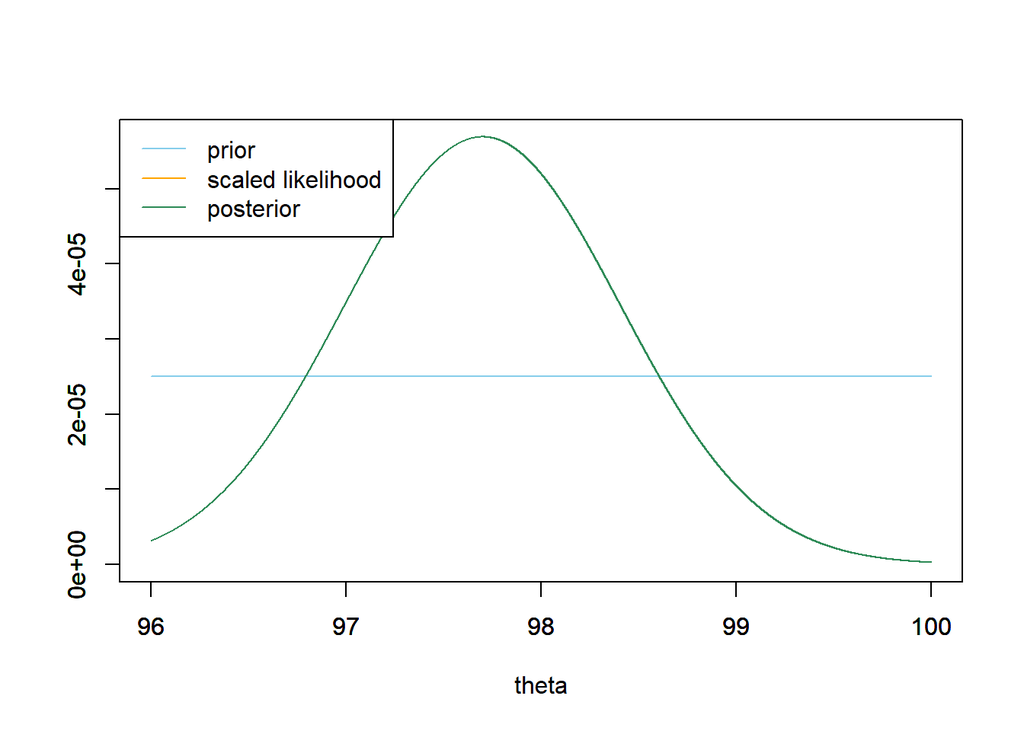

**Scenario 2:** Prior distribution is proportional to $2-|\theta - 98.0|$ over the possible values of $\theta$.

```r
### Type your code here. Feel free to add chunks as necessary
```

**TYPE YOUR RESPONSE HERE.**

```r
theta = seq(96, 100, 0.0001)

# prior
prior = 2 - abs(theta - 98) # shape of prior
prior = prior / sum(prior) # scales so that prior sums to 1

# data
n = 2 # sample size
y = 97.7 # sample mean

# likelihood, using Normal
sigma = 1
likelihood = dnorm(y, theta, sigma / sqrt(n)) # function of theta

# posterior
product = likelihood * prior
posterior = product / sum(product)

# posterior mean
posterior_mean = sum(theta * posterior)
posterior_mean
```

```
## [1] 97.81569
```

```r
# posterior_variance - "shortcut" formula
posterior_var = sum(theta ^ 2 * posterior) - posterior_mean ^ 2
posterior_sd = sqrt(posterior_var)
posterior_sd
```

```
## [1] 0.5540791
```

```r
# posterior percentiles - central 50% interval
theta[max(which(cumsum(posterior) < 0.25))]
```

```
## [1] 97.4433
```

```r
theta[max(which(cumsum(posterior) < 0.75))]
```

```
## [1] 98.1811
```

```r
# posterior percentiles - central 80% interval
theta[max(which(cumsum(posterior) < 0.1))]
```

```
## [1] 97.0928
```

```r
theta[max(which(cumsum(posterior) < 0.9))]
```

```
## [1] 98.5209
```

```r
# posterior percentiles - central 98% interval
theta[max(which(cumsum(posterior) < 0.01))]
```

```
## [1] 96.5356
```

```r
theta[max(which(cumsum(posterior) < 0.99))]
```

```
## [1] 99.1198
```

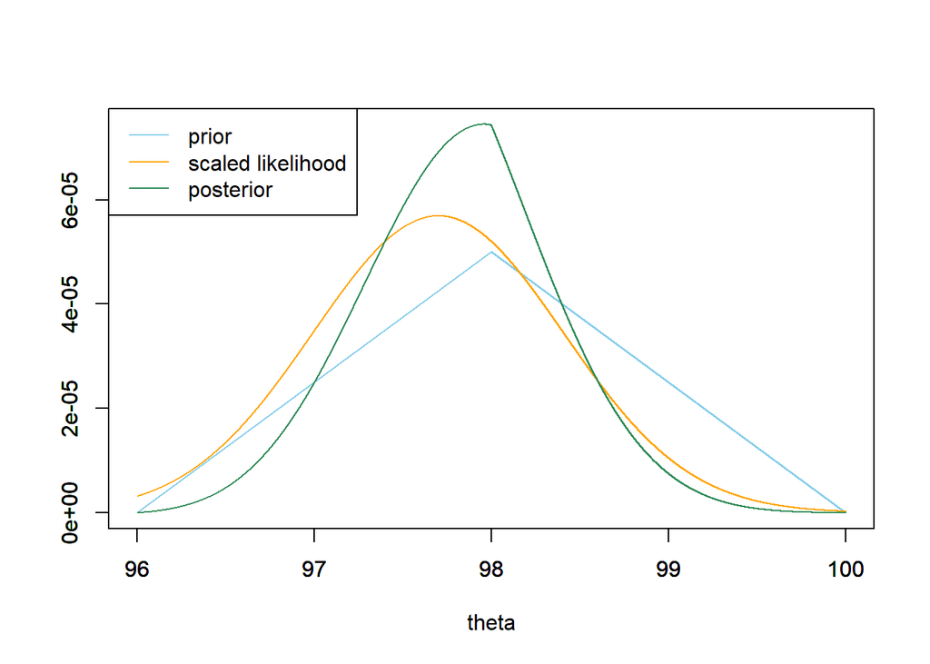

**Scenario 3:** Prior distribution is proportional to a Normal distribution with mean 98.6 and standard deviation 0.7 over the possible values of $\theta$. Careful: be sure not to confuse a Normal prior distribution with the likelihood.

```r
### Type your code here. Feel free to add chunks as necessary
```

**TYPE YOUR RESPONSE HERE.**

```r
theta = seq(96, 100, 0.0001)

# prior
prior = dnorm(theta, 98.6, 0.7) # shape of prior
prior = prior / sum(prior) # scales so that prior sums to 1

# data
n = 2 # sample size
y = 97.7 # sample mean

# likelihood, using Normal
sigma = 1
likelihood = dnorm(y, theta, sigma / sqrt(n)) # function of theta

# posterior
product = likelihood * prior
posterior = product / sum(product)

# posterior mean
posterior_mean = sum(theta * posterior)
posterior_mean
```

```
## [1] 98.15436
```

```r
# posterior_variance - "shortcut" formula
posterior_var = sum(theta ^ 2 * posterior) - posterior_mean ^ 2
posterior_sd = sqrt(posterior_var)
posterior_sd
```

```
## [1] 0.4970538
```

```r
# posterior percentiles - central 50% interval
theta[max(which(cumsum(posterior) < 0.25))]
```

```
## [1] 97.8189
```

```r
theta[max(which(cumsum(posterior) < 0.75))]
```

```
## [1] 98.4899
```

```r
# posterior percentiles - central 80% interval
theta[max(which(cumsum(posterior) < 0.1))]
```

```
## [1] 97.5169
```

```r
theta[max(which(cumsum(posterior) < 0.9))]
```

```
## [1] 98.7917
```

```r
# posterior percentiles - central 98% interval
theta[max(which(cumsum(posterior) < 0.01))]
```

```
## [1] 96.9973
```

```r
theta[max(which(cumsum(posterior) < 0.99))]
```

```
## [1] 99.3098
```

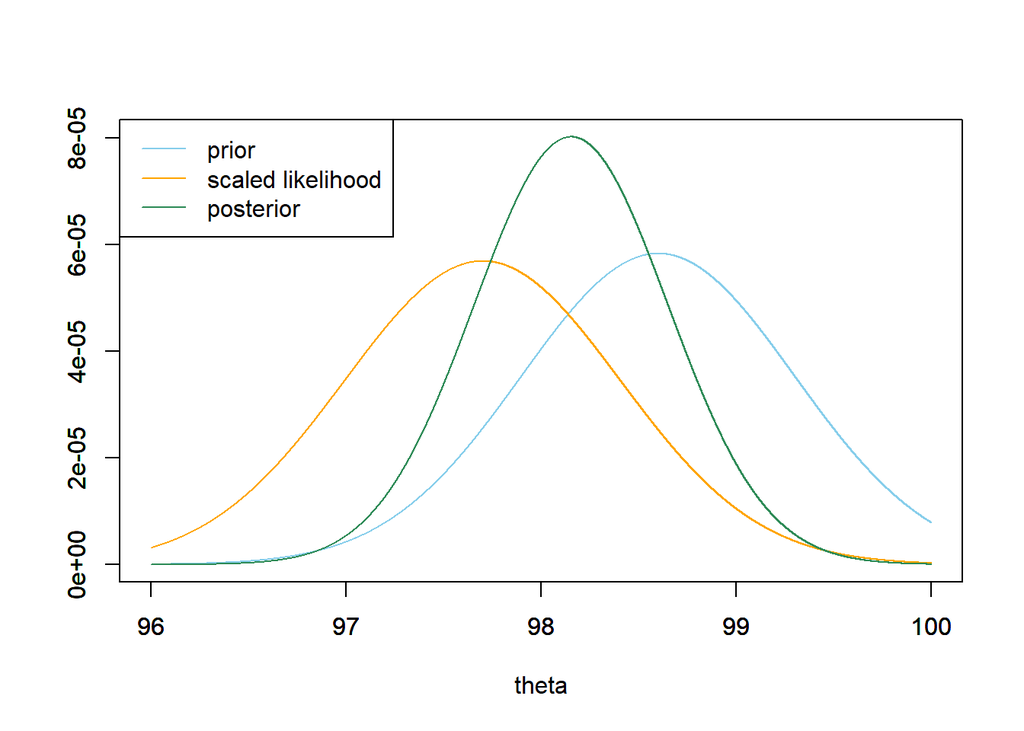

**Scenario 4:** Prior distribution is your choice!

```r
### Type your code here. Feel free to add chunks as necessary
```

**TYPE YOUR RESPONSE HERE.**

**Discussion.** Compare the posterior distributions from the scenarios above and discuss what influence the prior has on the results.

**TYPE YOUR RESPONSE HERE.**

Posterior is compromise between prior and likelihood.

# 9 Data Analysis

Continuing the body temperature example, now we’ll do a Bayesian analysis based on actual sample data.

We’ll again use a grid approximation and assume that any multiple of 0.0001 between 96.0 and 100.0 is a possible value of $\mu$: $96.0, 96.0001, 96.0002, \ldots, 99.9999, 100.0$.

Choose one of the prior distributions from the four scenarios in the previous section as the prior distribution.

In a recent study[^3], the sample mean body temperature in a sample of 208 healthy adults was 97.7 degrees F. You can assume this is a reasonably representative sample of healthy human body temperatures.

- Create a Bayes table to find the posterior distribution, but do NOT print the Bayes table.
- Create a plot of prior, likelihood, and posterior. (You can see the textbook for some examples, but you’re also welcome to create your own)
- Describe in words and with appropriate summary characteristics what the posterior distribution says about $\theta$.
- Write a few sentences summarizing your conclusions in context about $\theta$ based on your analysis.

```r
### Type your code here. Feel free to add chunks as necessary
```

**TYPE YOUR RESPONSE HERE.**

```r
theta = seq(96, 100, 0.0001)

# prior
prior = 2 - abs(theta - 98) # shape of prior
prior = prior / sum(prior) # scales so that prior sums to 1

# data
n = 208 # sample size
y = 97.7 # sample mean

# likelihood, using Normal
sigma = 1
likelihood = dnorm(y, theta, sigma / sqrt(n)) # function of theta

# posterior
product = likelihood * prior
posterior = product / sum(product)

# posterior mean
posterior_mean = sum(theta * posterior)
posterior_mean
```

```
## [1] 97.70283
```

```r
# posterior_variance - "shortcut" formula
posterior_var = sum(theta ^ 2 * posterior) - posterior_mean ^ 2
posterior_sd = sqrt(posterior_var)
posterior_sd
```

```
## [1] 0.06927973
```

```r
# posterior percentiles - central 50% interval
theta[max(which(cumsum(posterior) < 0.25))]
```

```
## [1] 97.656
```

```r
theta[max(which(cumsum(posterior) < 0.75))]
```

```
## [1] 97.7495
```

```r
# posterior percentiles - central 80% interval
theta[max(which(cumsum(posterior) < 0.1))]
```

```
## [1] 97.6139
```

```r
theta[max(which(cumsum(posterior) < 0.9))]
```

```
## [1] 97.7915
```

```r
# posterior percentiles - central 98% interval
theta[max(which(cumsum(posterior) < 0.01))]
```

```
## [1] 97.5416
```

```r
theta[max(which(cumsum(posterior) < 0.99))]
```

```
## [1] 97.8639
```

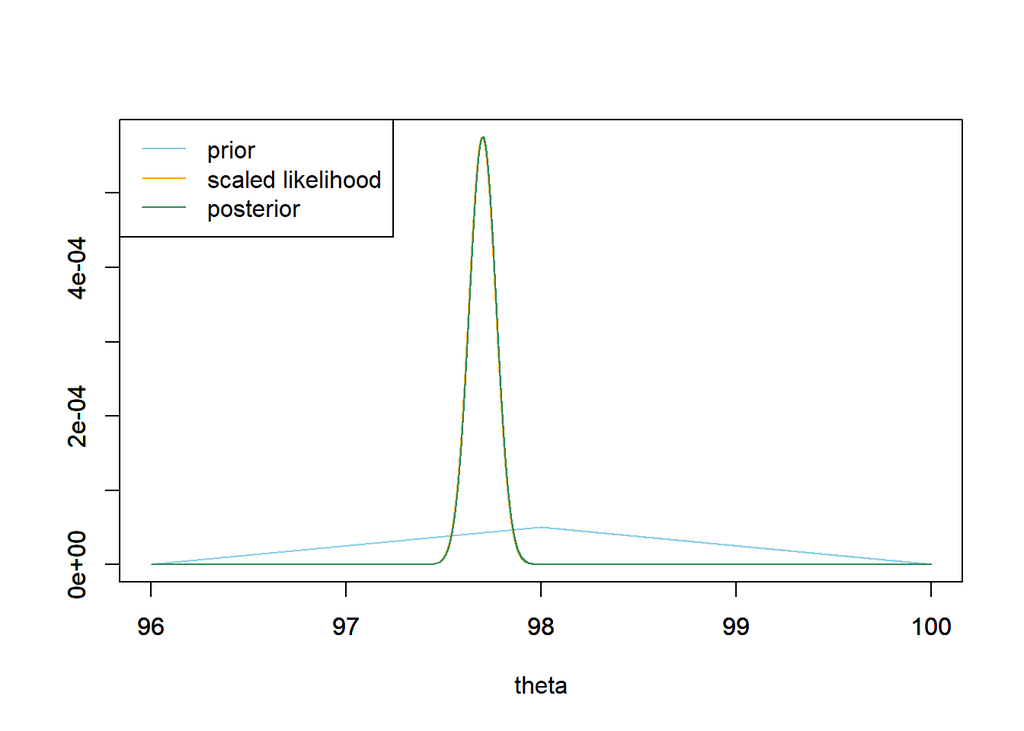

- The prior has very little influence on the posterior
- The posterior distribution is approximately Normal with posterior mean 97.7 and posterior SD 0.07.
- The small posterior SD concentrates plausibility around a fairly narrow ranges of values of $\theta$.
- There is posterior probability of 98% that population mean healthy human body temperature is between 97.54 and 97.86 degrees F.
- There is posterior probability pretty close to 100% that population mean healthy human body temperature is less than 98.6 degrees F.

# 10 Data Analysis: Sensitivity to prior

If you had chosen a different prior in the previous part, would your conclusions have changed substantially?

Redo the analysis from the previous part with a different prior from the four scenarios above. Choose whichever prior seems most different from the one you used in your data analysis in the previous section. (You can try all the other priors if you want, but you don’t have to.) Are the conclusions sensitive to the choice of prior?

```r
### Type your code here. Feel free to add chunks as necessary
```

**TYPE YOUR RESPONSE HERE.**

```r
theta = seq(96, 100, 0.0001)

# prior
prior = dnorm(theta, 98.6, 0.7) # shape of prior
prior = prior / sum(prior) # scales so that prior sums to 1

# data
n = 208 # sample size
y = 97.7 # sample mean

# likelihood, using Normal
sigma = 1
likelihood = dnorm(y, theta, sigma / sqrt(n)) # function of theta

# posterior
product = likelihood * prior
posterior = product / sum(product)

# posterior mean
posterior_mean = sum(theta * posterior)
posterior_mean
```

```
## [1] 97.70874
```

```r
# posterior_variance - "shortcut" formula
posterior_var = sum(theta ^ 2 * posterior) - posterior_mean ^ 2
posterior_sd = sqrt(posterior_var)
posterior_sd
```

```
## [1] 0.06899985
```

```r
# posterior percentiles - central 50% interval
theta[max(which(cumsum(posterior) < 0.25))]
```

```
## [1] 97.6621
```

```r
theta[max(which(cumsum(posterior) < 0.75))]
```

```
## [1] 97.7552
```

```r
# posterior percentiles - central 80% interval
theta[max(which(cumsum(posterior) < 0.1))]
```

```
## [1] 97.6202
```

```r
theta[max(which(cumsum(posterior) < 0.9))]
```

```
## [1] 97.7971
```

```r
# posterior percentiles - central 98% interval
theta[max(which(cumsum(posterior) < 0.01))]
```

```
## [1] 97.5481
```

```r
theta[max(which(cumsum(posterior) < 0.99))]
```

```
## [1] 97.8692
```

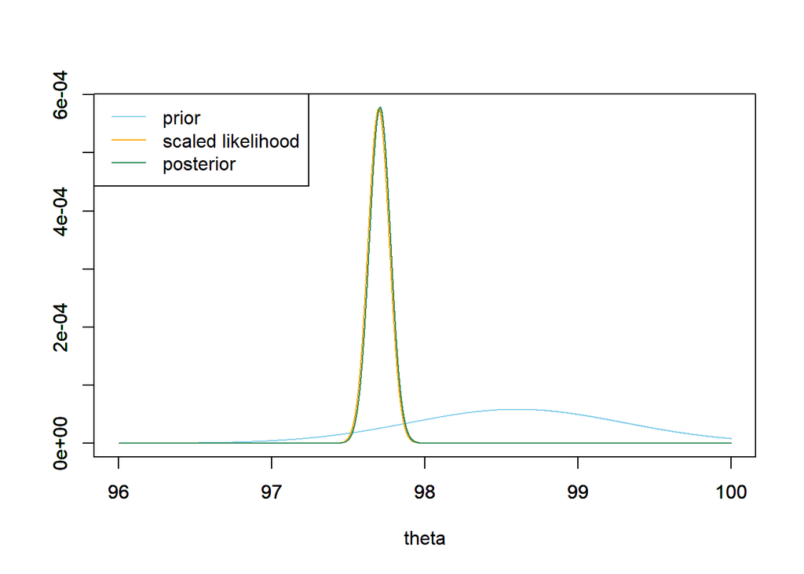

# 11 Comparison between Bayesian and frequentist results

Continue to assume $\sigma=1$ and the sample data with $n=208$ and $\bar{y}=97.7$. This section contains some exercises to compare the results and interpretations of Bayesian and frequentist analyses.

## 11.1 Interval estimates

Bayesian

- Compute a 95% central posterior credible interval for $\theta$.
- Write a clearly worded sentence containing the conclusion of the credible interval in context.
- Write a clearly worded sentence explaining what “95% credibility” means in context.

```r
### Type your code here. Feel free to add chunks as necessary
```

**TYPE YOUR RESPONSE HERE.**

Frequentist

- Compute a frequentist 95% confidence for $\theta$.
- Write a clearly worded sentence containing the conclusion of the confidence interval in context.
- Write a clearly worded sentence explaining what “95% confidence” means in context.

```r
### Type your code here. Feel free to add chunks as necessary
```

- We estimate with 95% confidence that population mean healthy human body temperature is between 97.56 and 97.84 degrees F.
- If many samples were selected and a 95% confidence interval computed based on each one, then 95% of the confidence intervals would contain the true population mean human body temperature.

**TYPE YOUR RESPONSE HERE.**

Write a few sentences comparing both the numerical results and the interpretations of the Bayesian and frequentist interval estimates.

Numerical values are similar. Interpretations are very different. Bayesian interval provides a probability statement about the parameter. Frequentist interval is based on what would happen over many samples.

**TYPE YOUR RESPONSE HERE.**

## 11.2 Bayesian posterior probability versus frequentist p-value

Bayesian

1. Compute the posterior probability that $\theta$ is less than 98.0.
2. Write a clearly worded sentence explaining what the posterior probability means in context.

```r
### Type your code here. Feel free to add chunks as necessary
```

**TYPE YOUR RESPONSE HERE.**

- There is posterior probability of 99.999% that population mean healthy human body temperature is less than 98.0 degrees F.
- We’d be willing to be a very large amount of money on it.

Frequentist

1. Conduct a one-sided frequentist hypothesis test of the null hypothesis $H_0: \theta = 98.0$ versus the alternative $H_a:\theta < 98.0$. Report the p-value.
2. Write a clearly worded sentence containing the conclusion of the hypothesis test in context.
3. Write a clearly worded sentence explaining what the p-value means in context.

```r
### Type your code here. Feel free to add chunks as necessary
```

**TYPE YOUR RESPONSE HERE.**

- A sample mean of 97.7 is -4.33 SDs below the hypothesized value.
- If population mean human body temperature is 98.0 then in less than 0.01% of samples the sample mean body temperature will be as extreme as 97.7.
- With a p-value less than 0.0001 there is strong evidence to reject the null hypothesis and conclude that population mean healthy human body temperature is less than 98.0

Write a few sentences comparing both the numerical results (posterior probability versus p-value) and the interpretations of the Bayesian and frequentist interval estimates.

**TYPE YOUR RESPONSE HERE.**

Bayesian can compute a probability that a hypothesis is true. p-value is confusing.

# 12 Reflection

1. Write a few sentences summarizing one important concept you have learned in this lab
2. What is (at least) one question that you still have?

**TYPE YOUR RESPONSE HERE.**

[^1]: Why $U$ and not $X$ or $Y$? In a Bayesian analysis, we might assume the data follows a Normal distribution, but we might also use a Normal distribution to quantify the uncertainty about a parameter. We generally associate $X$ and $Y$ with data. $U$ is supposed to represent a more general variable, which could be either data or a parameter.
[^2]: $\exp$ is just another way of writing the exponential function, $\exp(u)=e^u$.
[^3]: [Source](https://www.ncbi.nlm.nih.gov/pmc/articles/PMC6258625/) and a [related article](https://www.scientificamerican.com/article/are-human-body-temperatures-cooling-down/).